# PRÁCTICA 7: LEY DE POISEUILLE

**Autor responsable:** Pablo Corbalán de Concepción

**Autores**: Pablo Corbalán de Concepción y Víctor Mula Navarro.

**Grupo:** G4 - DTIE.

**Fecha del informe:** 26/03/2026.

## INFORMACIÓN GENERAL DEL LABORATORIO

**Fecha de realización de la práctica:** 26/03/2026.

**Temperatura:** 24.0ºC

**Humedad relativa:** 44%

**Presión:** 1025.7 hPa

## 1. INTRODUCCIÓN Y OBJETIVOS

La mecánica de fluidos es la rama de la física que se dedica a estudiar fluidos así como su comportamiento bajo diferentes condiciones. Ello nos permite someterlos a cambios de presión, temperatura, altura y observar cómo varía su flujo a través de un contenedor, que normalmente es un tubo. Así, somos capaces de extraer propiedades intrínsecas a cada fluido, como lo pueden ser su viscosidad, es decir, cómo se adhiere a las paredes del recipiente que lo contiene, o su densidad, siendo esta su relación entre su masa y volumen.

En particular, es curioso hacer un estudio de la diferencia existente cuando el fluido se encuentra en los conocidos como régimen laminar y régimen turbulento. El número de Reynolds nos indica en el régimen en el que está el fluido. Si es menor que 2300 aproximadamente, el régimen es laminar y, si es mayor a 4000, turbulento. Como dicho número es directamente proporcional a la velocidad del fluido (e inversamente proporcional a la viscosidad de este), en este experimento se trabajará con velocidades del fluido no muy elevadas para trabajar siempre en régimen laminar. De esta forma, serán eficaces las aproximaciones de primer orden realizadas en los cálculos teóricos.

Por tanto, esta práctica tiene como objetivos principales comprobar la validez de la Ley de Poiseuille y calcular experimentalmente el valor de la viscosidad del agua.

## 2. MARCO TEÓRICO GENERAL

Consideremos un tubo de igual sección en los extremos, por el que circula un fluido, con sus extremos A y B a la misma altura. Debido a efectos de viscosidad, entre los putnos A y B se crea una diferencia de presión $\Delta P$. El caudal que circula por el tubo depende del volumen que pasa por su sección por unidad de tiempo y viene dado por la expresión:

$$ Q = \frac{V}{t} \tag{1}$$

En caso de régimen laminar, la Ley de Poiseuille establece la siguiente relación:

$$ \Delta P = P_A - P_B = RQ \tag{2}$$

Siendo R la resistencia al flujo que ejerce el tubo. Si suponemos el tubo de sección constante y circular, podemos explicitar su valor mediante la expresión:

$$ R = \frac{8 \eta L}{\pi r^4} \tag{3}$$

Donde $\eta $ es el coeficiente de viscosidad del fluido, $L$ la longitud del tubo y $r$ el radio interno del mismo. Introduciendo esta expresión en ($2$):

$$ Q = \frac{\pi r^4}{8 \eta L} \Delta P \tag{4}$$

De esta forma, podremos hacer un ajuste por mínimos cuadrados de $Q$ frante a $\Delta P$ a fin de obtener el valor de $\eta$ de manera experimental.

Se tendrá en cuenta que el valor real de la viscosidad del agua es de $0.9 \cdot 10^{-3} Pa.s$ a una temperatura de 25 ºC

## 3. INSTRUMENTACIÓN Y MONTAJE EXPERIMENTAL

#### 3.1 MONTAJE EXPERIMENTAL

Dispondremos los materiales como se puede apreciar en la imagen siguiente

[figure not shown]

Primero, comenzamos pesando el vaso vacío para obtener su masa y midiendo la longitud del tubo que va desde A hasta B. Posteriormente, utilizaremos el vaso para recoger la cantidad de agua que sale del montaje durante una cantidad de tiempo dada que mediremos con el cronómetro digital. Una vez abramos la espita, la diferencia de alturas variará, lo que nos permitirá calcular la diferencia de presión entre los puntos A y B con la expresión:

$$ \Delta P = \rho g (L_B - L_A) = \rho g \Delta h \tag{5}$$

Siendo $L_A$ y $L_B$ la altura que alcanza el fluido sobre los puntos A y B, medida desde arriba. Repetiremos el experimento 10 veces, variando la velocidad a la que sale el agua del tubo, siempre sin superar una diferencia de altura superior a 5 cm.

#### 3.2 INSTRUMENTACIÓN

Los instrumentos empleados en la realización de este experimento han sido los siguientes:

- **Conducción con depósito de agua, tubos manométricos y espita**: Los tubos tienen una resolución de 0.1 cm.
- **Cronómetro digital**: El del teléfono móvil, con resolución de 0.01 s.
- **Balanza**: Empleada para determinar la masa del vaso con y sin agua. De resolución 0.01 g.
- **Vaso y cubeta de plástico**.
- **Cinta métrica**: Utilizada en la obtención de la longitud del tubo que une A y B. De resolución 0.1 cm.

## 4. RESULTADOS

### 4.1 MEDIDAS DIRECTAS

Las medidas obtenidas en el laboratorio han sido las siguientes:

[output not shown]

Donde:

- $L_A, L_B$: Altura de la columna de agua en los puntos A y B.
- $t$: Tiempo de recogida del caudal.
- $m$: Masa del vaso con el agua.

En lugar de tres medidas del tiempo y la masa, nos hemos limitado a tomar una medida de $(t, m)$ para cada $i$, simplificando así el experimento por el tiempo del que disponíamos.

### 4.2 REGRESIÓN LINEAL

A la hora de sacar las incertidumbres, comenzamos con la de la masa de agua. Sabemos

$$ u_{m_{agua}} = \sqrt{2}\cdot u_{balanza}$$

$$ u_{balanza} = \frac{\Delta}{\sqrt{12}}$$

Una vez obtenida esta incertidumbre, procedemos al cálculo de la del volumen. Mediante las derivadas parciales, obtenemos:

$$ u_V = \frac{\partial V}{\partial m} \cdot u_{m_{agua}} = \frac{1}{\rho_{agua}} \cdot u_{m_{agua}}$$

Por último, para hallar la incertidumbre asociada al cálculo final del caudal, volvemos a aplicar la propagación. El cálculo arroja:

$$ u_Q = Q \cdot \sqrt{\left(\frac{u_V}{V}\right)^2 +\left(\frac{u_t}{t}\right)^2}$$

Procedemos por tanto a realizar la regresión lineal, de la cual obtenemos la siguiente gráfica con la pendiente asociada:

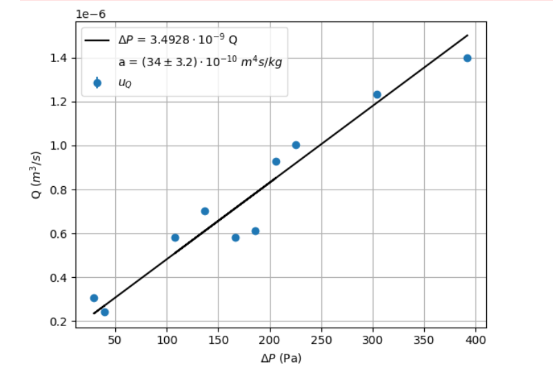

$$\boxed{a = (34 \pm 3.2)\cdot 10^{-10} \ m^4s/kg }$$

#### 4.2.2 Viscosidad del agua

Conocida la pendiente, utilizando la ecuación ($4$):

$$ a = \frac{\pi r^4}{8 \eta L} \implies \eta = \frac{\pi r^4}{8 a L} = 0.0046 \ Pa\cdot s$$

Si sacamos además su incertidumbre asociada:

$$ u_{\eta} = \eta \cdot \sqrt{\left(\frac{u_L}{L}\right)^2 + \left(\frac{u_a}{a}\right)^2 + 16 \cdot \left(\frac{u_r}{r}\right)^2}$$

Obteniendo finalmente un valor de:

$$\boxed{\eta = (4.6 \pm 2.3) \times 10^{-3} \text{ Pa}\cdot\text{s}}$$

### 5. Conclusiones

En esta práctica se ha comprobado experimentalmente la validez de la Ley de Poiseuille para el flujo de agua en régimen laminar. A través del análisis de los datos obtenidos en el laboratorio, se ha podido verificar la relación de proporcionalidad directa entre el caudal ($Q$) y la diferencia de presión ($\Delta P$) en el tramo de flujo laminar.

El ajuste por mínimos cuadrados realizado sobre los puntos identificados en régimen laminar proporcionó una pendiente de

$$ a = \frac{\pi r^4}{8 \eta L} = (34 \pm 3.2)\cdot 10^{-10} \ m^4s/kg $$

lo que muestra una correlación lineal satisfactoria que respalda el modelo teórico.

A partir de dicha pendiente y de las dimensiones geométricas del tubo ($r = 2.00 \pm 0.25$ mm y $L = 39.5 \pm 0.1$ cm), se determinó que la viscosidad experimental del agua es de

$$\eta = (4.6 \pm 2.3) \times 10^{-3} \text{ Pa}\cdot\text{s}$$

Dicha discrepancia no resulta excesiva si se considera que, más allá de la propagación de incertidumbres sistemáticas, factores experimentales como pequeñas fluctuaciones en el fluido o la formación de burbujas pueden alterar sensiblemente la medición de la viscosidad. Identificamos, además, que probablemente la mayor fuente de error proviene de la medición del radio interno del tubo. Dado que este parámetro aparece elevado a la cuarta potencia en la ecuación de la viscosidad

$$\eta = \frac{\pi r^4}{8 a L}$$

Cualquier pequeña imprecisión en su medida, en nuestro caso $u_r = 0.25$ mm se propaga de forma crítica al resultado final, como se refleja en la incertidumbre relativa de $\eta$.

Asimismo, para caudales mayores se observó una desviación de la linealidad, lo cual es coherente con el inicio de la transición hacia un régimen turbulento donde el número de Reynolds $n_R$ supera el límite laminar.

En conclusión, la metodología empleada ha permitido caracterizar con éxito la viscosidad del fluido, destacando la importancia de la precisión en las medidas geométricas del sistema.

### 6. Bibliografía

Laboratorio de física experimental. (2026). *Guión Práctica 7: Ley de Poiseuille. Guion de laboratorio*. Universidad de Murcia.

## 7. ANEXOS

En los anexos los cálculos no se han explicitado siguiendo la convención de dos cifras significativas en la incertidumbre (con la magnitud ajustada a las cifras significativas correspondientes). Así se puede comprobar que el redondeo se ha hecho correctamente. En el cuerpo del informe sí se ha seguido esta convención.

```python
import numpy as np
import matplotlib.pyplot as plt
from scipy.odr import *
```

```python
rho_agua = 1 # g/cm^3
g = 9.80 # m/s^2
rho_agua_SI = 1000 # kg/m^3
```

```python
l_tubo = 39.5 #cm
l_a = [14.5, 15.4, 18.6, 19.8, 26.2, 23.3, 21.5, 27.7, 36.7, 41.3] # cm
l_b = [14.9, 15.7, 20.3, 21.7, 28.3, 24.7, 22.6, 30.0, 39.8, 45.3] # cm
d_h = [l_b[i] - l_a[i] for i in range(len(l_a))] # cm
d_h_m = [elemento/100 for elemento in d_h] # m

t = [120.13, 119.98, 120.10, 119.56, 120.13, 120.39, 120.06, 60.03, 60.07, 60.32] # s

m = [48.66, 56.13, 89.27, 92.78, 131.24, 104.11, 89.15, 79.68, 93.60, 103.98] # g
m_vaso = 19.55 #g
m_agua = [(m[i] - m_vaso)*0.001 for i in range(len(m))]

V_agua_SI = [m_agua[i]/rho_agua_SI for i in range(len(m))] # m^3

d_P = [rho_agua_SI*g*altura for altura in d_h_m] # Pa

Q = [V_agua_SI[i]/t[i] for i in range (len(t))]
```

```python
# INCERTIDUMBRES

def uB_digital(res):
    return res/np.sqrt(12)

def uB (res):
    return res/np.sqrt(24)

def uA (s, N):
    return s/np.sqrt(N)

def u_combinada (u_a, u_b):
    return np.sqrt(pow(u_a, 2)+ pow(u_b, 2))

def imprimir (lista, unidades, titulo = ""):
    print(titulo)
    for i in range(len(lista)):
        print(f"{i+1} : {lista[i]} {unidades}")

u_balanza = uB_digital(0.01)
u_metro = uB(0.1)
u_tiempos = uB_digital (0.01)

u_m_agua = (np.sqrt(2)*u_balanza)*0.001 #kg
u_V_agua_SI = u_m_agua/rho_agua_SI

u_Q = [Q[i]*np.sqrt(pow((u_V_agua_SI)/V_agua_SI[i], 2)+ pow((u_tiempos)/t[i], 2)) for i in range(len(t))]
```

```python
# IMPRIMIR

imprimir(Q, r"$m^3/s$", "Caudal")
imprimir(u_Q, r"$m^3/s$", "Incertidumbre Caudal")
```

```
Caudal
1 : 2.42320819112628e-07 $m^3/s$
2 : 3.0488414735789294e-07 $m^3/s$
3 : 5.805162364696087e-07 $m^3/s$
4 : 6.124958179993309e-07 $m^3/s$
5 : 9.297427786564556e-07 $m^3/s$
6 : 7.023839189301438e-07 $m^3/s$
7 : 5.797101449275363e-07 $m^3/s$
8 : 1.001665833749792e-06 $m^3/s$
9 : 1.2327284834359915e-06 $m^3/s$
10 : 1.3997015915119364e-06 $m^3/s$
Incertidumbre Caudal
1 : 3.447914408082639e-11 $m^3/s$
2 : 3.480810630569924e-11 $m^3/s$
3 : 3.674477921507416e-11 $m^3/s$
4 : 3.721080751277867e-11 $m^3/s$
5 : 4.0670206031888584e-11 $m^3/s$
6 : 3.78625614109358e-11 $m^3/s$
7 : 3.674966568221864e-11 $m^3/s$
8 : 8.333796319165409e-11 $m^3/s$
9 : 9.015703144501394e-11 $m^3/s$
10 : 9.522474535107956e-11 $m^3/s$
```

```python
# REGRESIÓN LINEAL

def Lineal (parameters, x):
    A, B = parameters
    y = np.multiply(A, x) +B
    return y

lin_model = Model(Lineal)
data = RealData(d_P, Q, sy = u_Q)
odr = ODR(data, lin_model, beta0 = [0.,1.])
out = odr.run()
out.pprint()
```

```
Beta: [3.49240319e-09 1.32287704e-07]
Beta Std Error: [3.27774109e-10 6.77210940e-08]
Beta Covariance: [[ 1.15832861e-22 -2.07708257e-20]
 [-2.07708257e-20  4.94459157e-18]]
Residual Variance: 927.5076638311463
Inverse Condition #: 0.023592529556026778
Reason(s) for Halting:
  Sum of squares convergence
```

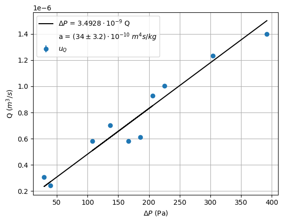

```python
fit_y = Lineal(out.beta, d_P)
plt.errorbar(d_P, Q, yerr= u_Q, linestyle = "None", marker = 'o', label = r"$u_Q$")
plt.plot(d_P, fit_y, label = r"$\Delta P$ = $3.4928 \cdot 10^{-9}$ Q", color = "black")
plt.plot([],[], linestyle = "None", label = "a = $(34 \pm 3.2)\cdot 10^{-10}$ $m^4 s/kg$")
plt.xlabel (r"$\Delta P$ (Pa)")
plt.ylabel(r"Q ($m^3/s$)")
plt.grid()
plt.legend()
plt.show()
```

```python
# CÁLCULO DE LA VISCOSIDAD DEL AGUA
r = 2 * 1e-3          # m
u_r = 0.25 * 1e-3     # m
L = l_tubo / 100
u_L = u_metro / 100

# Pendiente
a = out.beta[0]
u_a = out.sd_beta[0]

eta = (np.pi * pow(r, 4)) / (8 * a * L)

u_eta = np.abs(eta) * np.sqrt(pow(u_L / L, 2) + pow(u_a / a, 2) + 16 * pow(u_r / r, 2))

print(f"Viscosidad (η): {eta:.6e} Pa·s")
print(f"Incertidumbre (u_η): ± {u_eta:.6e} Pa·s")
```

```
Viscosidad (η): 4.554686e-03 Pa·s
Incertidumbre (u_η): ± 2.317116e-03 Pa·s
```

```python
# CÁLCULO DEL ERROR RELATIV DE LA VISCOSIDAD
eta_teorica = 0.0009 # VALOR A 25ºC
err_eta = (eta_teorica - eta/ eta_teorica)
print(f"Error relativo (tanto por uno): {err_eta:.2f} ")
```

```
Error relativo (tanto por uno): -5.06
```